# Assignment 2

# Task 1: Dimension reduction on air quality data

## Part A: Get

- Obtain data from https://archive.ics.uci.edu/dataset/360/air+quality.

```r
df <- read.table( "AirQualityUCI.csv", header=TRUE, sep=";")
```

**Provide a brief description of the data based on the information from the website.**

## Part B: Import and Visualize

- Load the data and convert to tsibble.
  - Make sure dates and hours are converted into proper time objects
  - Remove incomplete days at beginning and end of data

```r
df <- df %>%
  filter(!(as.Date(datetime) %in% as.Date(c("2004-03-10", "2005-04-04"))))

df <- df %>%
  mutate(across(where(is.character), ~ as.numeric(gsub(",", ".", .))))

tsib_df <- as_tsibble(df, index = "datetime")
print(tsib_df)
```

```
## # A tsibble: 9,336 x 14 [1h] <UTC>
##    CO.GT. PT08.S1.CO. NMHC.GT. C6H6.GT. PT08.S2.NMHC. NOx.GT. PT08.S3.NOx.
##     <dbl>       <int>    <int>    <dbl>         <int>   <int>        <int>
##  1    1.2        1185       31      3.6           690      62         1462
##  2    1          1136       31      3.3           672      62         1453
##  3    0.9        1094       24      2.3           609      45         1579
##  4    0.6        1010       19      1.7           561    -200         1705
##  5 -200          1011       14      1.3           527      21         1818
##  6    0.7        1066        8      1.1           512      16         1918
##  7    0.7        1052       16      1.6           553      34         1738
##  8    1.1        1144       29      3.2           667      98         1490
##  9    2          1333       64      8             900     174         1136
## 10    2.2        1351       87      9.5           960     129         1079
## # ℹ 9,326 more rows
## # ℹ 7 more variables: NO2.GT. <int>, PT08.S4.NO2. <int>, PT08.S5.O3. <int>,
## #   T <dbl>, RH <dbl>, AH <dbl>, datetime <dttm>
```

- **Plot the data as is, preferably as multiple panels in a single plot**

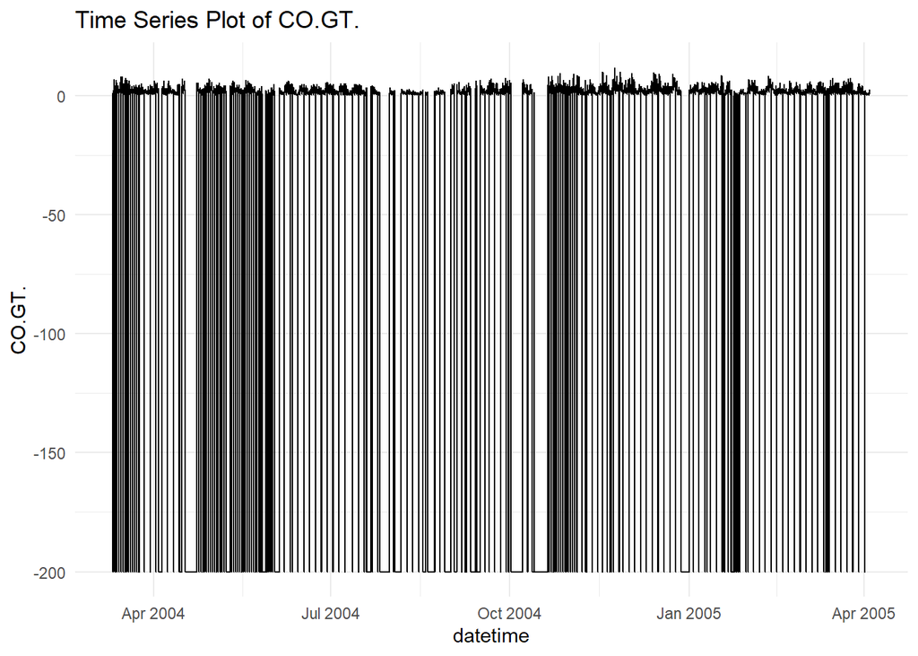

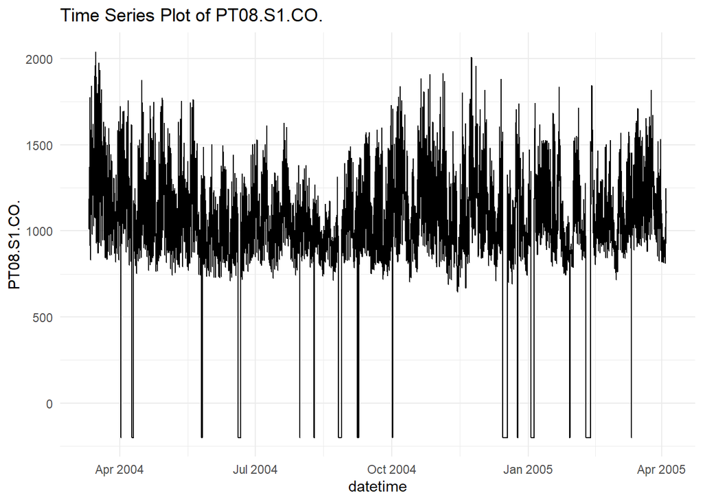

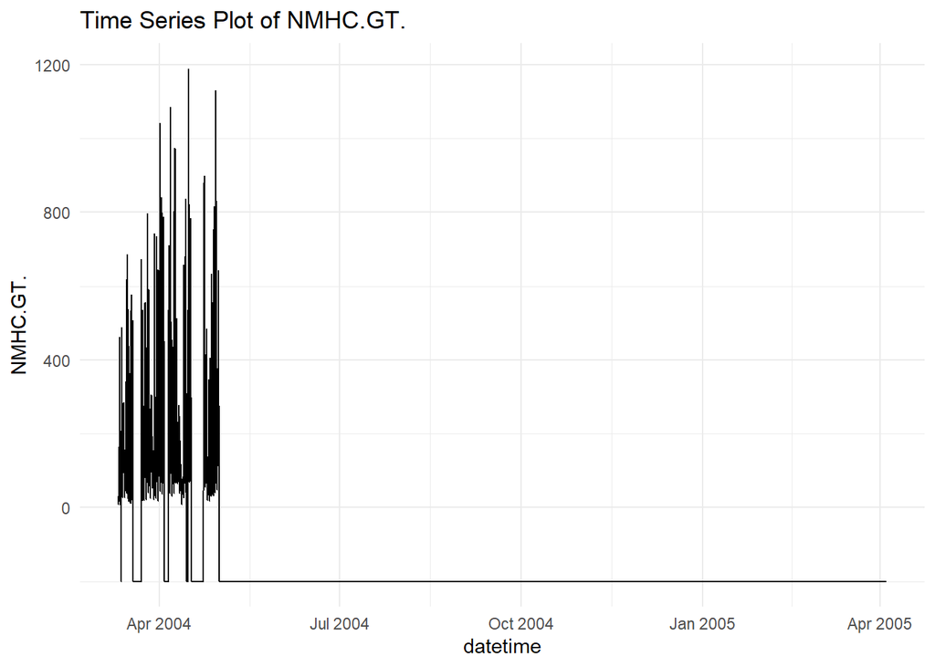

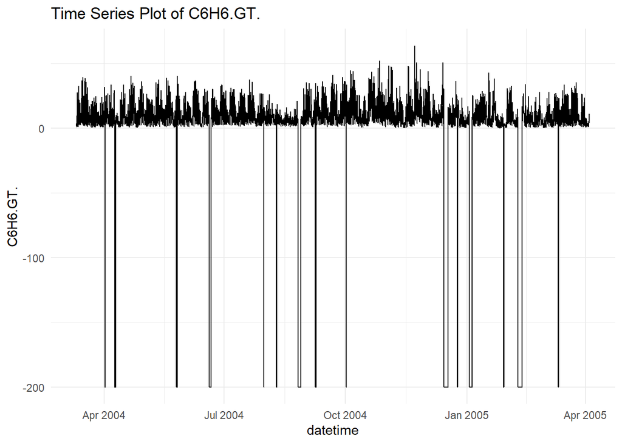

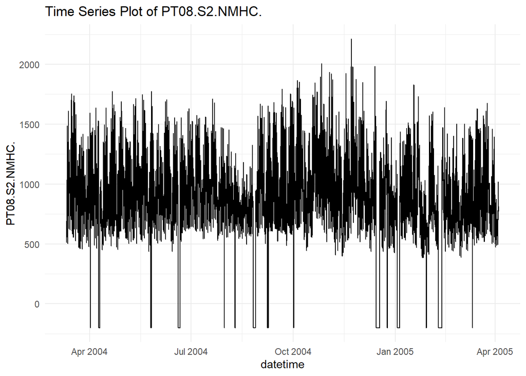

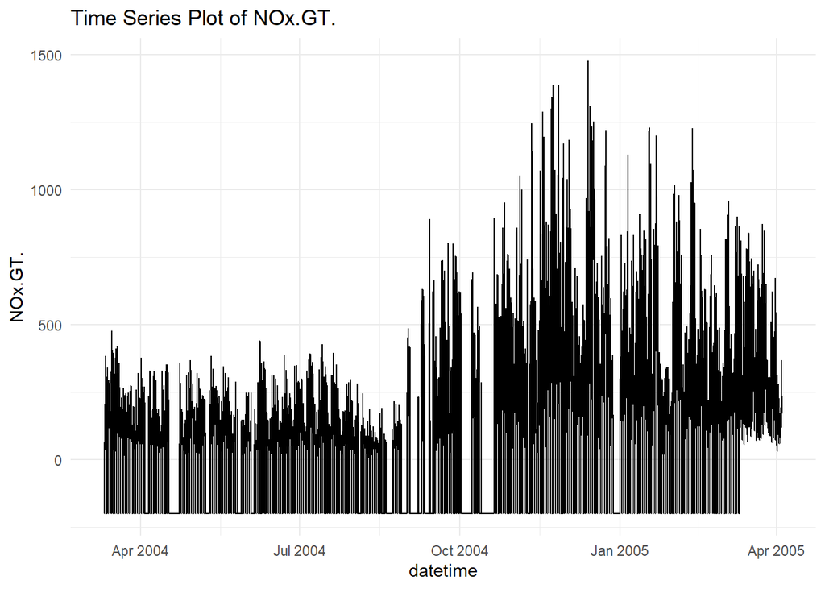

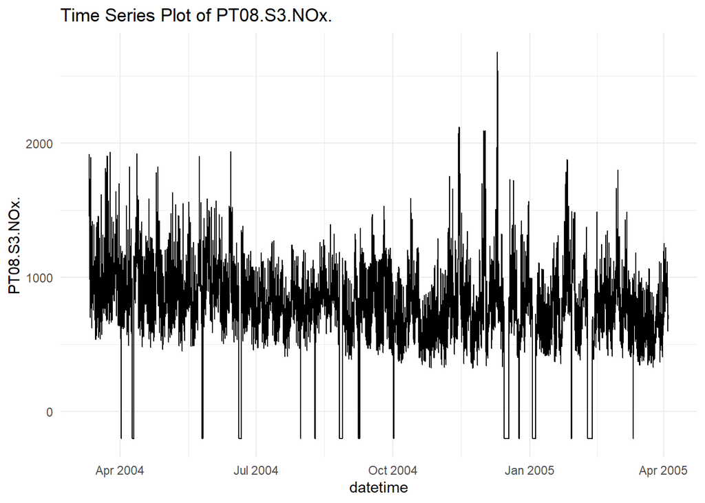

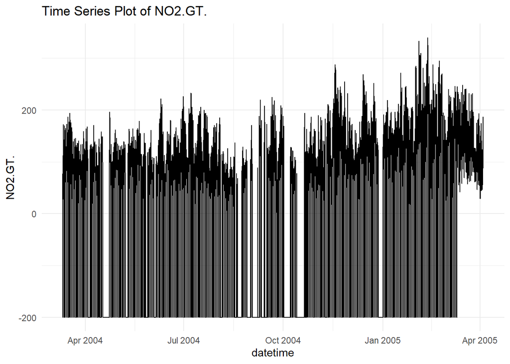

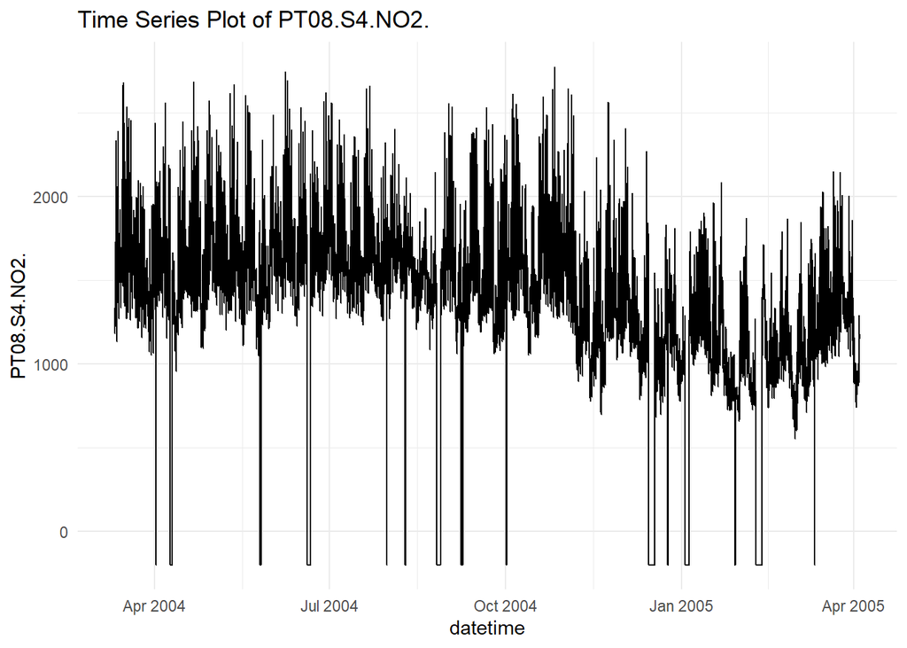

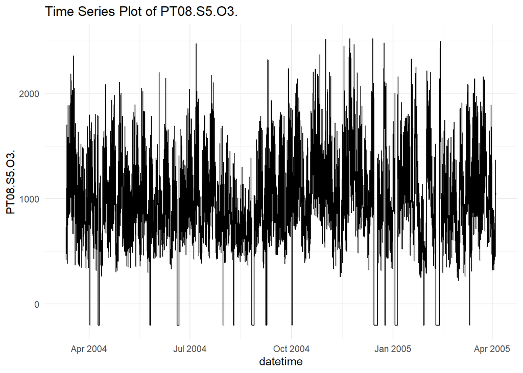

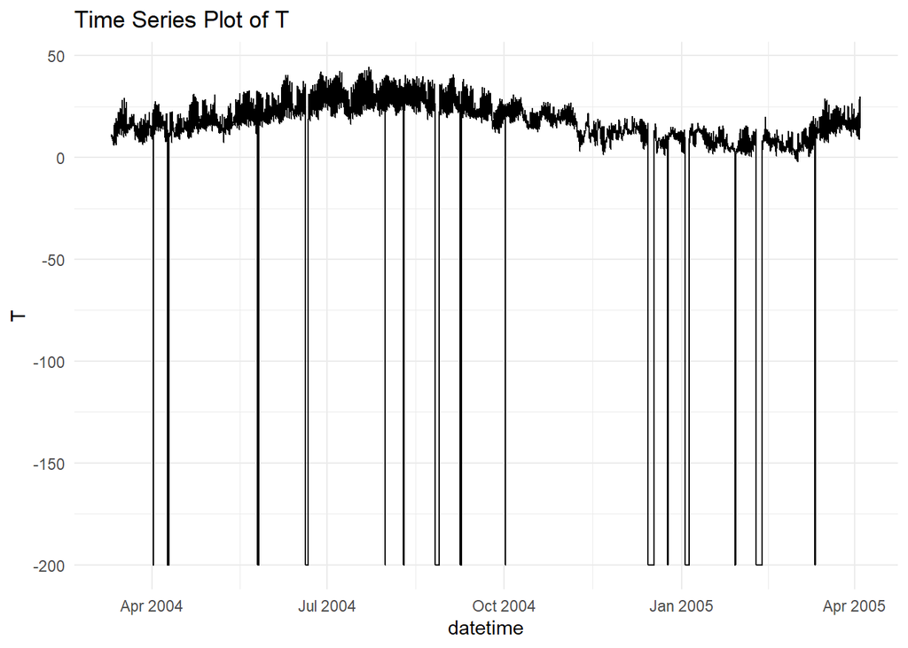

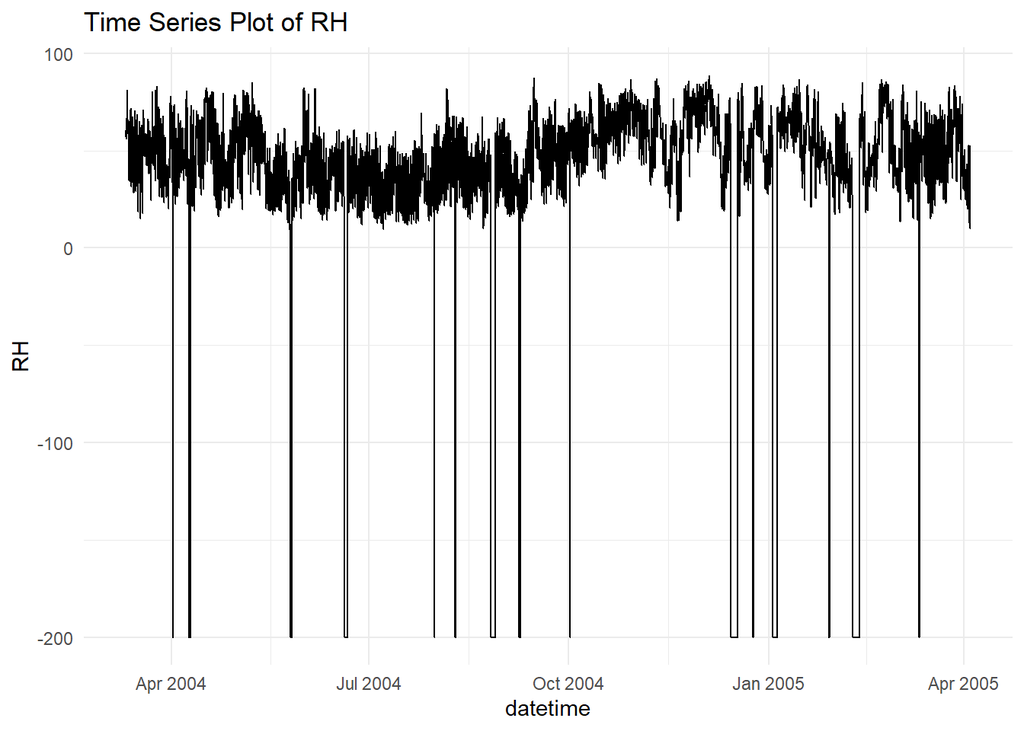

[1 more figures not shown]

```r
library(ggplot2)
library(dplyr)
for (col in colnames(tsib_df)) {
  if (col == "datetime") {
    next
  }
    p <- ggplot(tsib_df, aes_string(x = "datetime", y = col)) +
      geom_line() +
      labs(title = paste("Time Series Plot of", col),
           y = col) +
      theme_minimal()
    print(p)
  }
```

The plot of each column, shows where na’s occure. In the dataset it is denoted as -200.

```r
na_counts <- sapply(tsib_df, function(x) sum(x == -200, na.rm = TRUE))
na_counts <- na_counts[order(-na_counts)]

cat(sprintf("Amount of cols: %d \n", length(na_counts)))
```

```
## Amount of cols: 14
```

```r
cat("Amount of missing values in each column\n")
```

```
## Amount of missing values in each column
```

```r
for (col in names(na_counts)) {
  count <- na_counts[col]
  if (count > 0) {

    cat(sprintf("%-13s : %d amount\n", col, count))
  }
}
```

```
## NMHC.GT.      : 8428 amount
## CO.GT.        : 1682 amount
## NO2.GT.       : 1642 amount
## NOx.GT.       : 1639 amount
## PT08.S1.CO.   : 366 amount
## C6H6.GT.      : 366 amount
## PT08.S2.NMHC. : 366 amount
## PT08.S3.NOx.  : 366 amount
## PT08.S4.NO2.  : 366 amount
## PT08.S5.O3.   : 366 amount
## T             : 366 amount
## RH            : 366 amount
## AH            : 366 amount
```

## Part C: PCA of data as is

- Perform PCA on the data as prepared in B
- Create a screeplot and create biplots for 1st and 2nd and for 2nd and 3rd PCs
- Plot the scores for the PCs
- Comment on the results. Can you relate some features to your observations in part B?

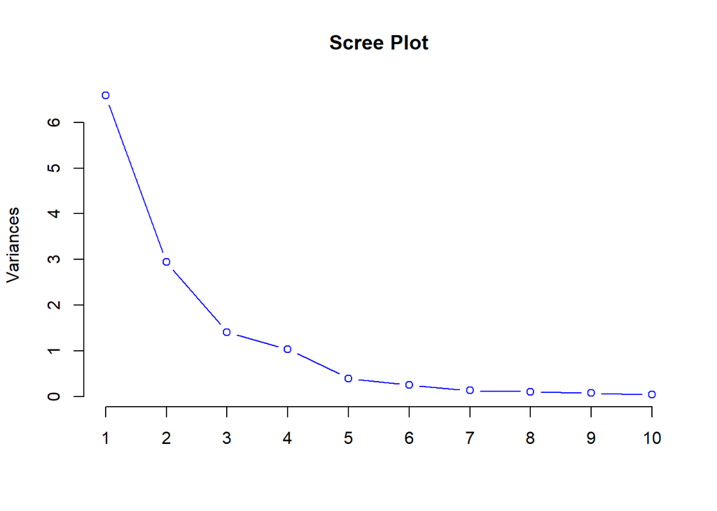

```r
library(tsibble)
library(dplyr)
library(ggfortify)
library(tidyr)

# Perform PCA
pc <- prcomp(tsib_df[, names(tsib_df)!="datetime"], scale=TRUE)

screeplot(pc, main = "Scree Plot", col = "blue", type = "lines")
```

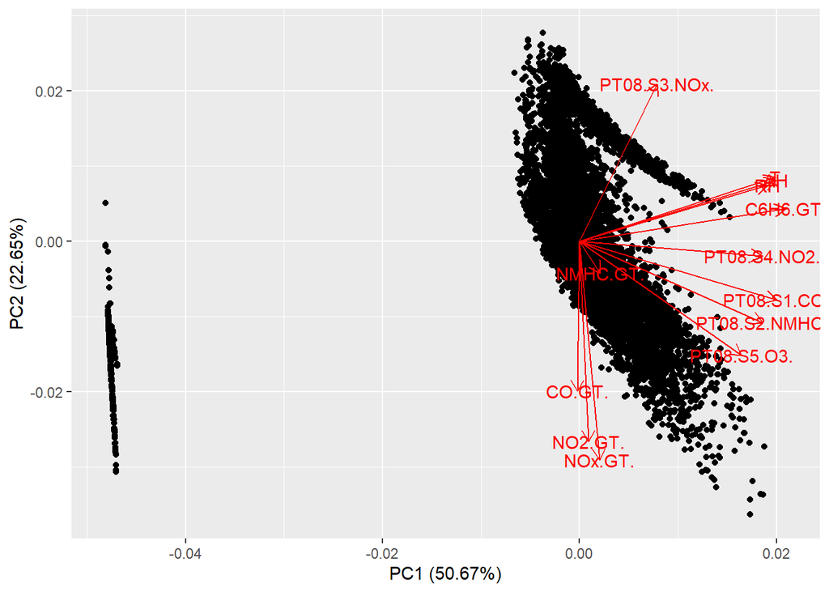

```r
autoplot(pc, loadings.label=TRUE)
```

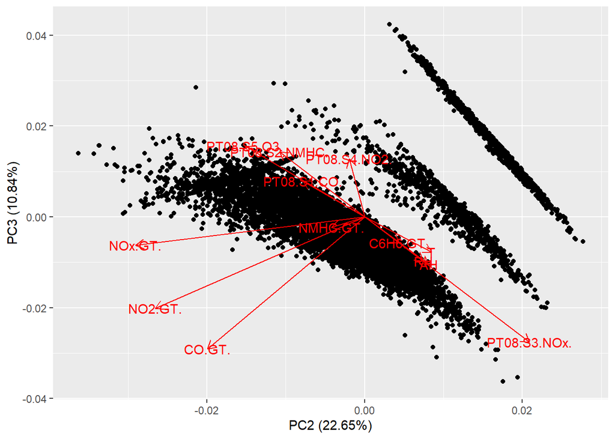

```r
autoplot(pc, x=2, y = 3, loadings.label=TRUE)
```

See that the screeplot generate a fast falling curve that stales towards 0, which is to be expected, since most variance will be captured in the first component, and then less and less moving on.

For the PC1 and PC2, we suspect that the PC1 is separating the NAN values and rest of the dataset. And PC2 is catching some variance within that.

For the PC2 and PC3, there is separated into 3 clusters, where we suspect that upper right is all NAN values. Some of the .GT columns seems to be a bit independent regarding when NAN values occur, therefore we suspect that they contribute more to the second cluster.The orthogonality away from the other measurements might only come from the Nan values, and not true variance.

As mentioned earlier, the NMHC.GT has many NAN values, and by looking at its small loading we notice that it is not contributing alot.

## Part D: Missing values

- **Identify missing values in the time series** Mentioned under describe the data in Part B
- **Investigate to which degree missing values occur at the same time for multiple sensors**

```r
missing_df <- tsib_df[tsib_df$PT08.S1.CO. ==-200, ] # Finding the index where PT08 is returning NAN

for (feature in colnames(missing_df)){
  a <- sum(missing_df[[feature]]==-200)
  cat(sprintf("%-13s : %-6.0f null values \n", feature, a ))
}
```

```
## CO.GT.        : 36     null values
## PT08.S1.CO.   : 366    null values
## NMHC.GT.      : 339    null values
## C6H6.GT.      : 366    null values
## PT08.S2.NMHC. : 366    null values
## NOx.GT.       : 44     null values
## PT08.S3.NOx.  : 366    null values
## NO2.GT.       : 44     null values
## PT08.S4.NO2.  : 366    null values
## PT08.S5.O3.   : 366    null values
## T             : 366    null values
## RH            : 366    null values
## AH            : 366    null values
## datetime      : 0      null values
```

```r
missing_df <- tsib_df[tsib_df$NO2.GT. ==-200, ] # Finding the index where PT08 is returning NAN

for (feature in colnames(missing_df)){
  a <- sum(missing_df[[feature]]==-200)
  cat(sprintf("%-13s : %-6.0f null values \n", feature, a ))
}
```

```
## CO.GT.        : 1226   null values
## PT08.S1.CO.   : 44     null values
## NMHC.GT.      : 1605   null values
## C6H6.GT.      : 44     null values
## PT08.S2.NMHC. : 44     null values
## NOx.GT.       : 1639   null values
## PT08.S3.NOx.  : 44     null values
## NO2.GT.       : 1642   null values
## PT08.S4.NO2.  : 44     null values
## PT08.S5.O3.   : 44     null values
## T             : 44     null values
## RH            : 44     null values
## AH            : 44     null values
## datetime      : 0      null values
```

- **Is one or are multiple sensors behaving peculiarly? How would you handle this?** By comparing the indexes of where PTO8.S1.CO is returning NAN, with the other columns as well, we see that our suspicion regarding several failing at the same time is confirmed. All sensors from the multi sensor has 366 missing values, have the failing at the same indexes.

The GT sensors, are also higly correlated in where they return NAN. (CO.GT, NOx.GT and NO2.GT)

- Discuss options for handling missing values: (a) drop all time points containing any missing value, (b) impute values for missing values. In case of (b) choose a method for imputation. Justify your decisions.

**Creating dataset, removing all NAN values**

```r
tsib_df_no_NMHC <- tsib_df %>%
  select(-NMHC.GT.)

# Print the size of the original data frame
original_size <- dim(tsib_df_no_NMHC)
cat("Original Size: Rows =", original_size[1], ", Columns =", original_size[2], "\n")
```

```
## Original Size: Rows = 9336 , Columns = 13
```

```r
tsib_df_no_NMHC[tsib_df_no_NMHC == -200] <- NA

# Filter out rows with NA and store the result in a new data frame
tsib_df_no_NMHC = tsib_df_no_NMHC %>%
  drop_na()


# Print the size of the filtered data frame
filtered_size <- dim(tsib_df_no_NMHC)
cat("Filtered Size: Rows =", filtered_size[1], ", Columns =", filtered_size[2], "\n")
```

```
## Filtered Size: Rows = 6921 , Columns = 13
```

```r
cat("Rows removed: ", original_size[1] - filtered_size[1], "\n")
```

```
## Rows removed:  2415
```

- At the end of this step, you should have a version of the data containing only valid values. Plot these data as in Part B.

## Part E: PCA of cleaned data

- Perform PCA on the data as prepared in D
- Create a screeplot and biplots for 1st/2nd, 2nd/3rd, 3rd/4th PC

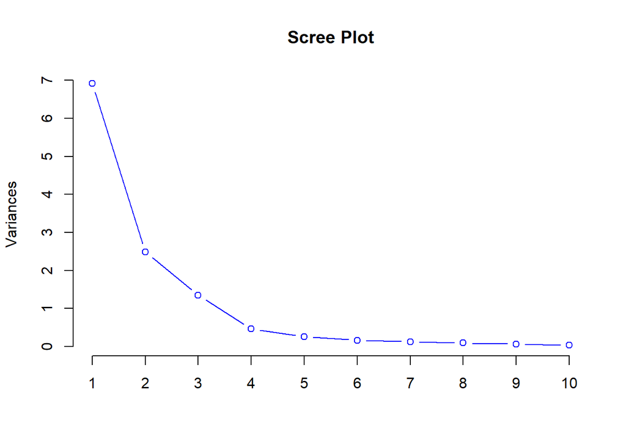

```r
library(tsibble)
library(dplyr)
library(ggfortify)

pc_cleaned <- prcomp(tsib_df_no_NMHC[, names(tsib_df_no_NMHC)!="datetime"], scale=TRUE)

screeplot(pc_cleaned, main = "Scree Plot", col = "blue", type = "lines")
```

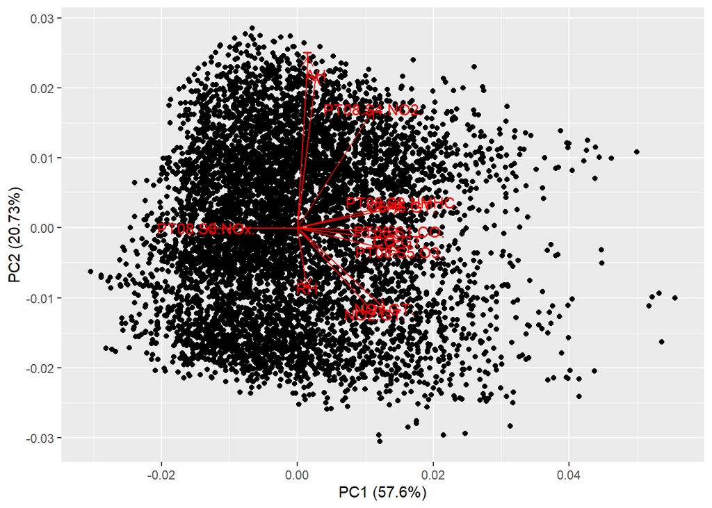

```r
autoplot(pc_cleaned, loadings.label=TRUE)
```

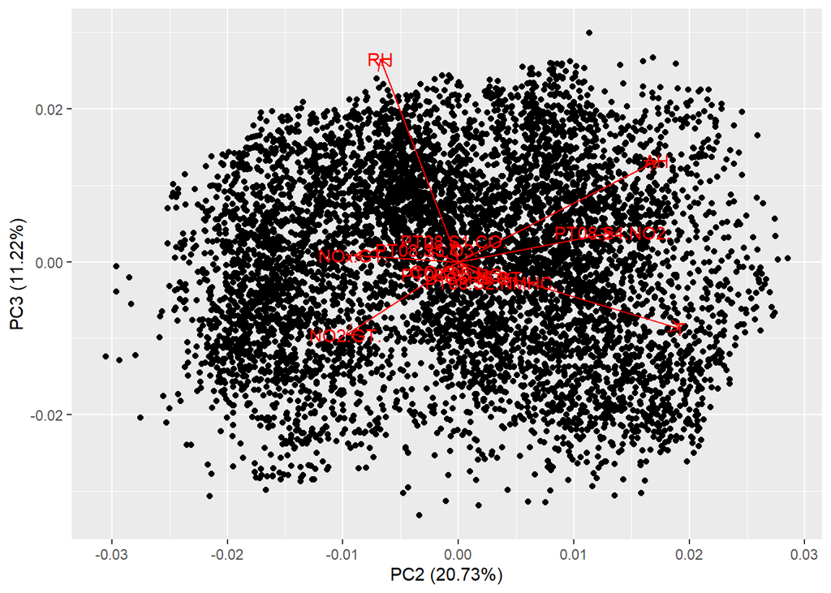

```r
autoplot(pc_cleaned, x=2, y = 3, loadings.label=TRUE)
```

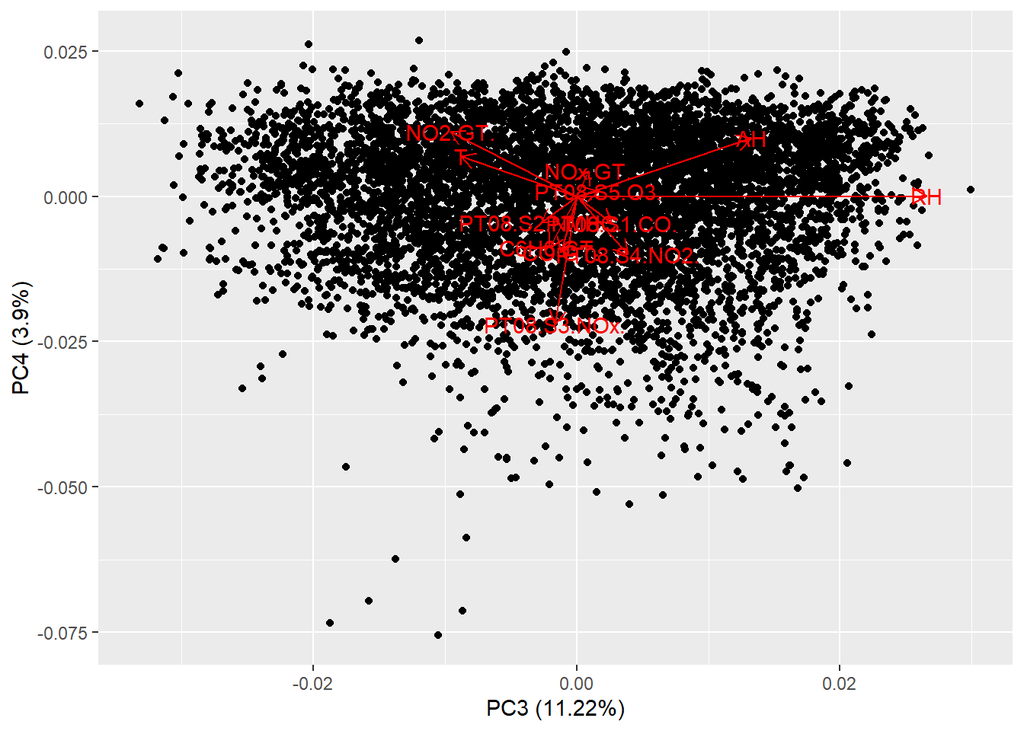

```r
autoplot(pc_cleaned, x=3, y = 4, loadings.label=TRUE)
```

After the removal of the NAN values, there is no longer a clear clustering in the components.

- Compute total variance explained by 1st, 1st and 2nd, 1st to 3rd, … PCs
- Choose how many PCs to keep and transform data back to original sample space

```r
variance_explained <- summary(pc_cleaned)$importance[2, ]
variance_explained
```

```
##     PC1     PC2     PC3     PC4     PC5     PC6     PC7     PC8     PC9    PC10
## 0.57597 0.20727 0.11219 0.03903 0.02155 0.01365 0.01071 0.00799 0.00538 0.00301
##    PC11    PC12
## 0.00242 0.00081
```

```r
total_variance_pc1_pc2 <- sum(variance_explained[1:2])
total_variance_pc1_pc3 <- sum(variance_explained[1:3])
total_variance_pc1_pc4 <- sum(variance_explained[1:4])

cat("Total variance explained by PC1 -> PC2: ", round(total_variance_pc1_pc2 * 100, 2), "%\n")
```

```
## Total variance explained by PC1 -> PC2:  78.32 %
```

```r
cat("Total variance explained by PC1 -> PC3: ", round(total_variance_pc1_pc3 * 100, 2), "%\n")
```

```
## Total variance explained by PC1 -> PC3:  89.54 %
```

```r
cat("Total variance explained by PC1 -> PC4: ", round(total_variance_pc1_pc4 * 100, 2), "%\n")
```

```
## Total variance explained by PC1 -> PC4:  93.45 %
```

Using 3 PCS, since from 4 and further on, not much of the variance is explained.

```r
reconstructed_data <- t(t(pc_cleaned$x[, 1:3] %*% t(pc_cleaned$rotation[, 1:3])) * pc_cleaned$scale + pc_cleaned$center)
reconstructed_df <- as.data.frame(reconstructed_data)
reconstructed_df$datetime <- tsib_df_no_NMHC$datetime
```

- Plot the result against the cleaned data, compare and discuss

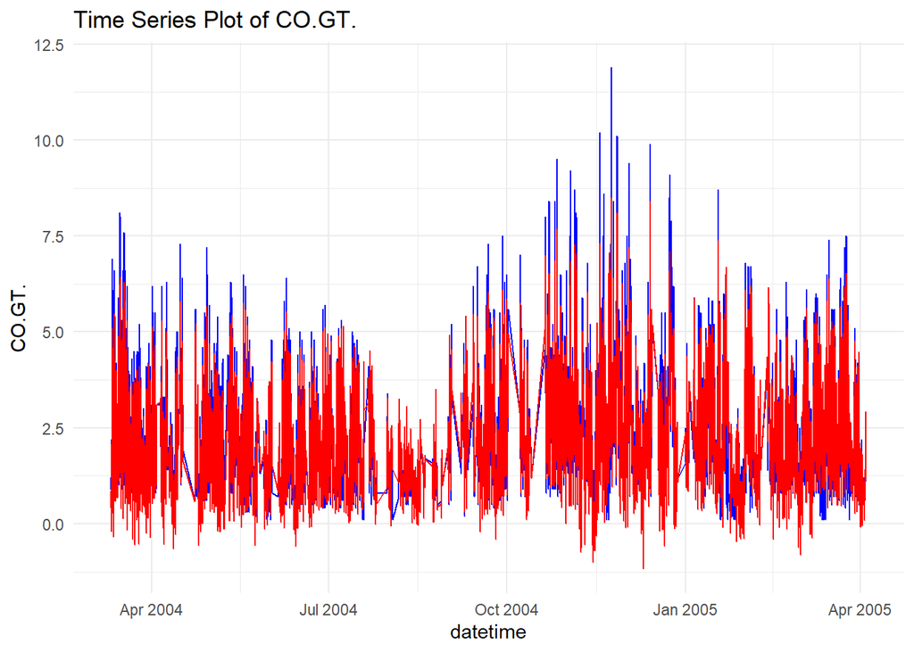

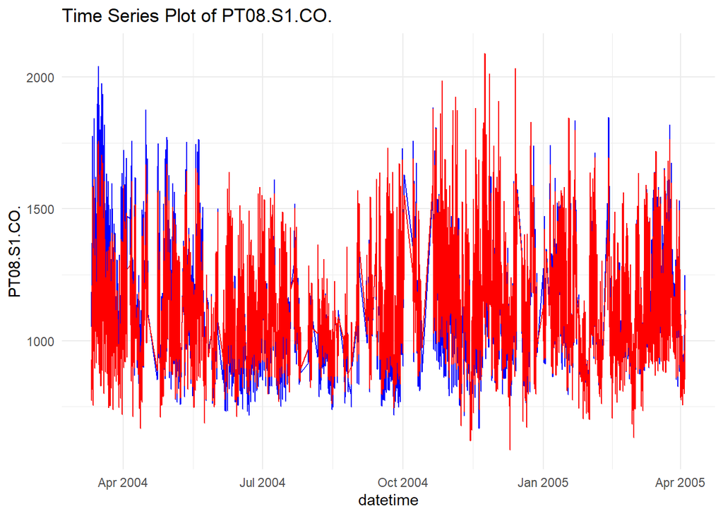

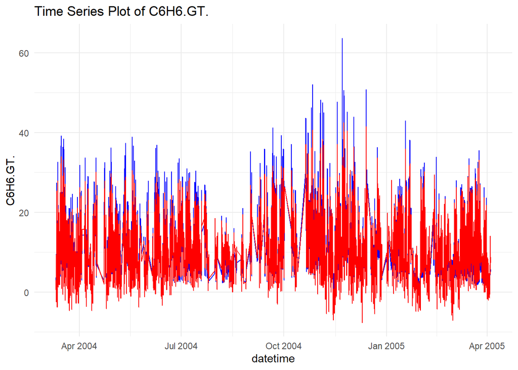

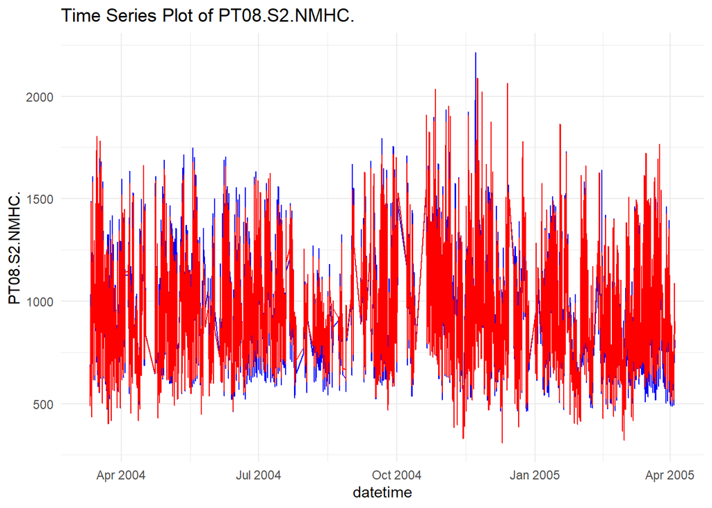

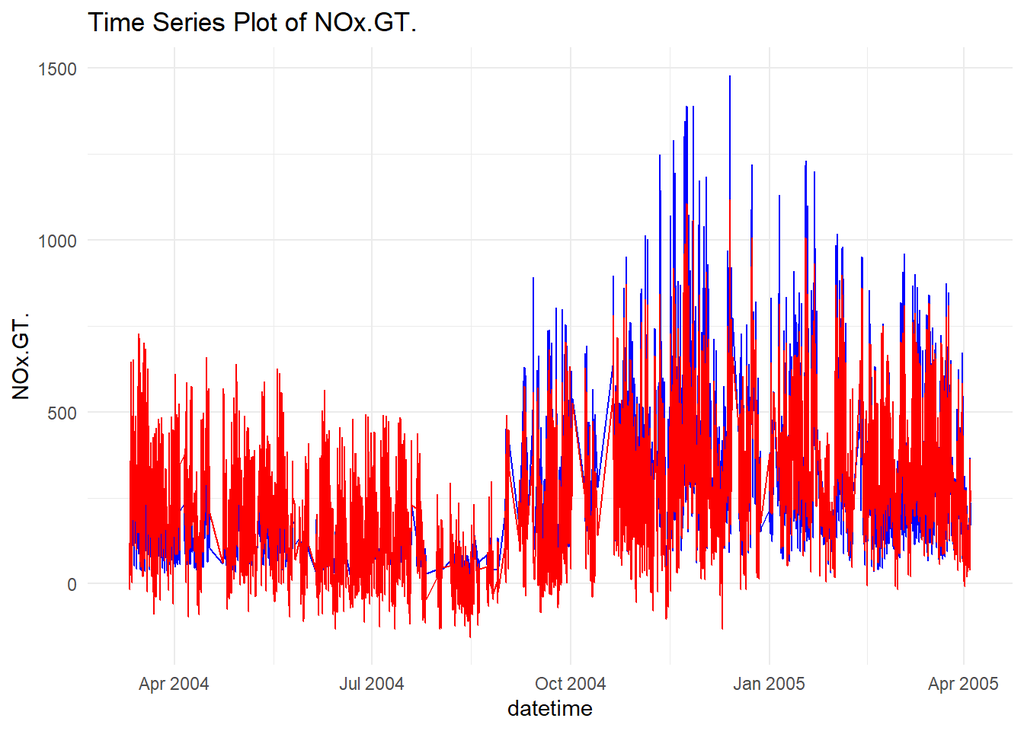

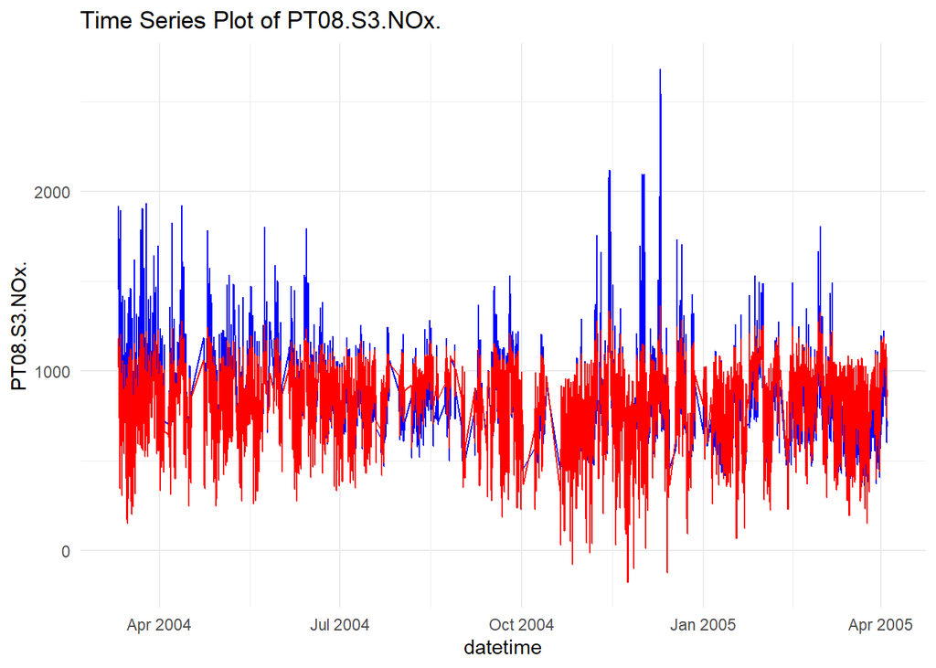

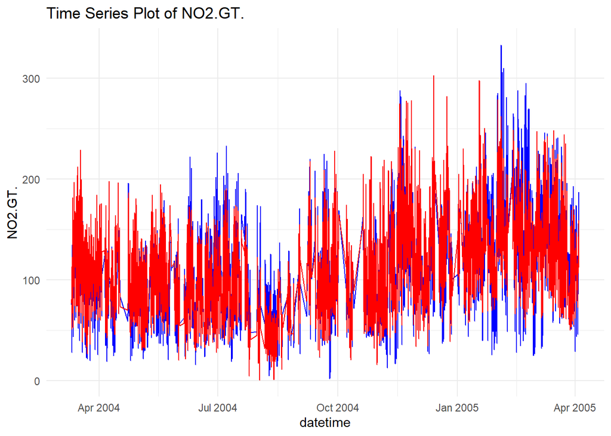

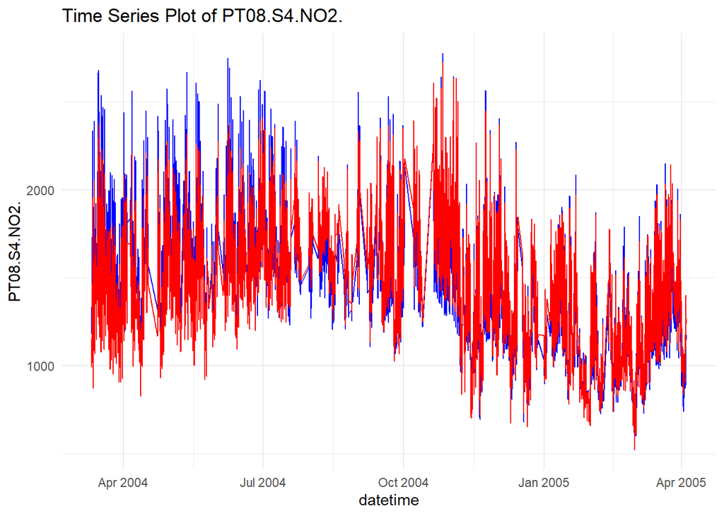

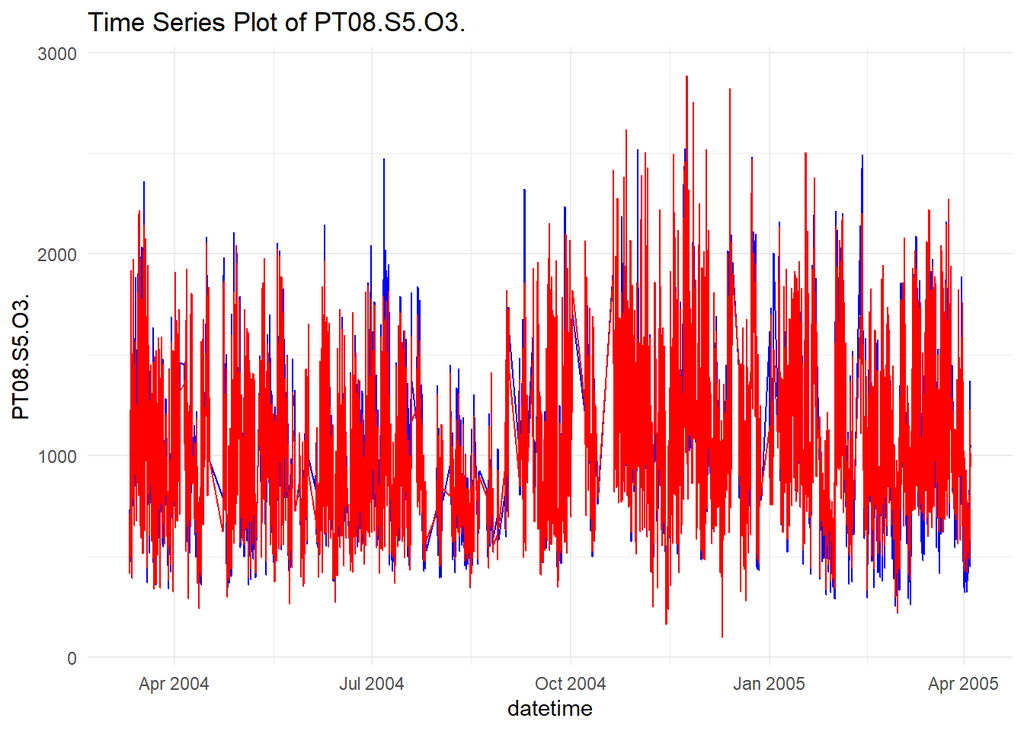

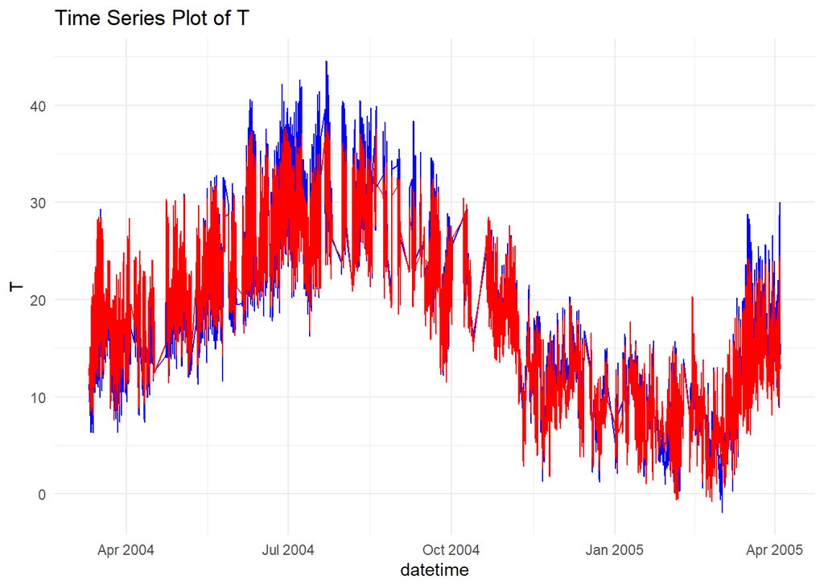

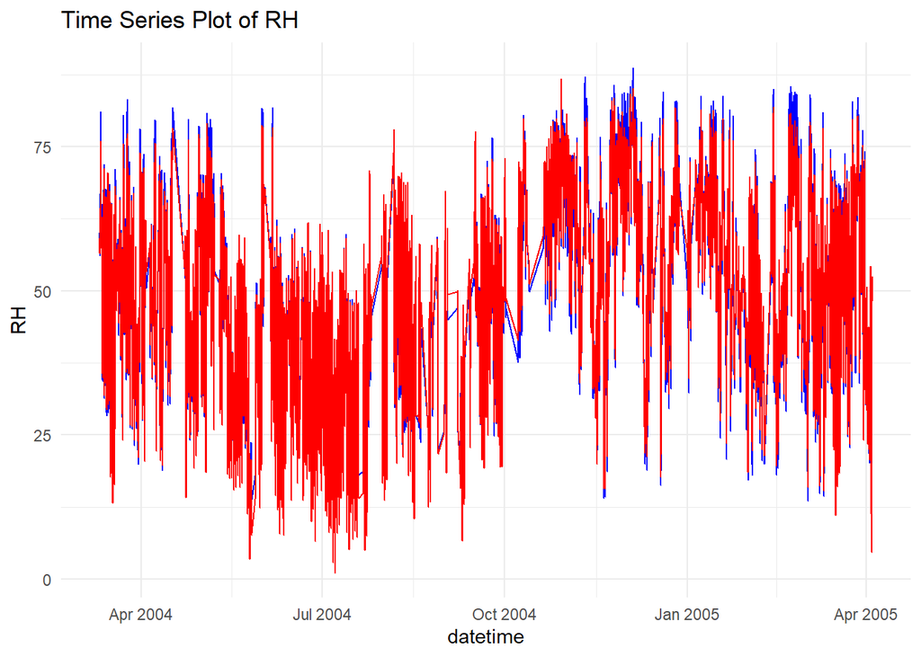

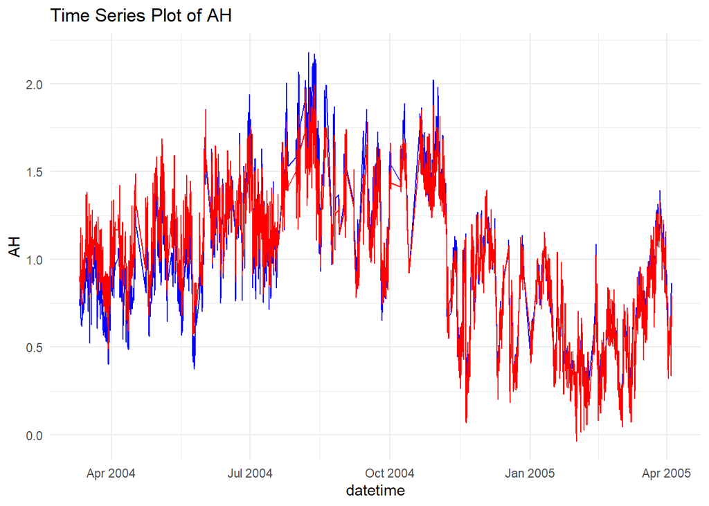

```r
#Plot columns from reconstructed_df and tsib_df_no_NMHC against each other
for (col in colnames(reconstructed_df[names(reconstructed_df)!="datetime"])) {

  p <- ggplot() +
    geom_line(data = tsib_df_no_NMHC, aes_string(x = "datetime", y = col), color = "blue") +
    geom_line(data = reconstructed_df, aes_string(x = "datetime", y = col), color = "red") +
    labs(title = paste("Time Series Plot of", col),
         y = col) +
    theme_minimal()
  print(p)}
```